# Final_Uniquant_ExponentialMovingAverage

## Exponential Moving Average

```python
import pandas as pd
import numpy as np
import matplotlib.pyplot as plt
```

```python
data = pd.read_csv('reduced_df.csv', header=0, index_col=0)
```

**We First Split the Dataset into X and y**

```python
X = data[['f_0','f_1','f_2','f_3','f_4','f_5','f_6','f_7','f_8','f_9','f_10','f_11','f_12','f_13','f_14','f_15','f_16','f_17',
'f_18','f_19','f_20','f_21','f_22','f_23','f_24','f_25','f_26','f_27','f_28','f_29','f_30','f_31','f_32','f_33','f_34','f_35',
'f_36','f_37','f_38','f_39','f_40','f_41','f_42','f_43','f_44','f_45','f_46','f_47','f_48','f_49','f_50','f_51','f_52','f_53',
'f_54','f_55','f_56','f_57','f_58','f_59','f_60','f_61','f_62','f_63','f_64','f_65','f_66','f_67','f_68','f_69','f_70','f_71',
'f_72','f_73','f_74','f_75','f_76','f_77','f_78','f_79','f_80','f_81','f_82','f_83','f_84','f_85','f_86','f_87','f_88','f_89',
'f_90','f_91','f_92','f_93','f_94','f_95','f_96','f_97','f_98','f_99','f_100','f_101','f_102','f_103','f_104','f_105','f_106',
'f_107','f_108','f_109','f_110','f_111','f_112','f_113','f_114','f_115','f_116','f_117','f_118','f_119','f_120','f_121','f_122',
'f_123','f_124','f_125','f_126','f_127','f_128','f_129','f_130','f_131','f_132','f_133','f_134','f_135','f_136','f_137','f_138',
'f_139','f_140','f_141','f_142','f_143','f_144','f_145','f_146','f_147','f_148','f_149','f_150','f_151','f_152','f_153','f_154',
'f_155','f_156','f_157','f_158','f_159','f_160','f_161','f_162','f_163','f_164','f_165','f_166','f_167','f_168','f_169','f_170',
'f_171','f_172','f_173','f_174','f_175','f_176','f_177','f_178','f_179','f_180','f_181','f_182','f_183','f_184','f_185','f_186',
'f_187','f_188','f_189','f_190','f_191','f_192','f_193','f_194','f_195','f_196','f_197','f_198','f_199','f_200','f_201','f_202',
'f_203','f_204','f_205','f_206','f_207','f_208','f_209','f_210','f_211','f_212','f_213','f_214','f_215','f_216','f_217','f_218',
'f_219','f_220','f_221','f_222','f_223','f_224','f_225','f_226','f_227','f_228','f_229','f_230','f_231','f_232','f_233','f_234',
'f_235','f_236','f_237','f_238','f_239','f_240','f_241','f_242','f_243','f_244','f_245','f_246','f_247','f_248','f_249','f_250',
'f_251','f_252','f_253','f_254','f_255','f_256','f_257','f_258','f_259','f_260','f_261','f_262','f_263','f_264','f_265','f_266',
'f_267','f_268','f_269','f_270','f_271','f_272','f_273','f_274','f_275','f_276','f_277','f_278','f_279','f_280','f_281','f_282',
'f_283','f_284','f_285','f_286','f_287','f_288','f_289','f_290','f_291','f_292','f_293','f_294','f_295','f_296','f_297','f_298',
'f_299']]

y = data['target']
```

**Due to the Presence of 300 Features within the Dataset, we apply Pricipal Component Analysis (PCA) in order to reduce the Dimensionality of the Dataset from 300 to 50 Features**

```python
from sklearn.decomposition import PCA

pca = PCA(n_components = 50)
X_new = pca.fit_transform(X)
explained_variance = pca.explained_variance_ratio_
```

```python
X_new
```

```
array([[  5.93077122,   2.82407956,  -6.39142171, ...,  -0.44589903,
         -0.09831979,   0.51433603],
       [ -1.97908196,   5.20564115,   4.76911092, ...,   0.086774  ,
          0.57508857,   0.20385691],
       [  0.06088423,  -0.20815699,  -5.46241029, ...,   0.63229762,
         -0.20086473,  -0.64028355],
       ...,
       [-11.15120698,   5.97159757,   0.41326315, ...,  -0.09120071,
          0.09024051,   1.24434229],
       [-10.62579612,  -2.91714448,  -0.38626926, ...,  -0.10463291,
         -0.03915451,  -1.13528728],
       [ -3.81431941,  -4.78487459,  -0.36581512, ...,  -0.05607134,
          0.02466476,   0.20560544]])
```

```python
X_new_df = pd.DataFrame(X_new)
```

**We make a New DataFrame consisting of the reduced features and the Target Variable**

```python
new_df = pd.concat([X_new_df, y], axis=1)
new_df
```

|  | 0 | 1 | 2 | 3 | 4 | 5 | 6 | 7 | 8 | 9 | ... | 41 | 42 | 43 | 44 | 45 | 46 | 47 | 48 | 49 | target |
| --- | --- | --- | --- | --- | --- | --- | --- | --- | --- | --- | --- | --- | --- | --- | --- | --- | --- | --- | --- | --- | --- |
| 0 | 5.930771 | 2.824080 | -6.391422 | -0.642594 | 0.846280 | 0.198923 | 2.039745 | 1.618830 | -2.733179 | -1.212043 | ... | -1.108339 | 0.480669 | 2.125531 | -0.027982 | -1.051851 | -1.235880 | -0.445899 | -0.098320 | 0.514336 | -0.300875 |
| 1 | -1.979082 | 5.205641 | 4.769111 | 1.021434 | -2.399475 | -4.065784 | -0.409557 | -1.588492 | -1.065897 | -0.094282 | ... | 0.571065 | 0.810281 | 1.751607 | -1.667070 | -0.889234 | 0.704316 | 0.086774 | 0.575089 | 0.203857 | -0.231040 |
| 2 | 0.060884 | -0.208157 | -5.462410 | 2.508520 | 3.332386 | -1.066268 | 0.668043 | -0.327550 | -2.105577 | 0.333458 | ... | -0.205397 | -0.730531 | -0.108195 | 0.732693 | -0.436894 | -0.175075 | 0.632298 | -0.200865 | -0.640284 | 0.568807 |
| 3 | -8.785642 | 5.701729 | -2.182929 | -1.501637 | -1.258420 | 0.732030 | 3.611673 | 0.650930 | 0.581523 | -1.092464 | ... | 0.408868 | 0.332666 | 0.093810 | 0.503546 | 1.576630 | -1.214367 | 0.672053 | 0.948136 | 1.548149 | -1.064780 |
| 4 | -13.456921 | -1.051679 | -1.098696 | -2.687386 | -1.377818 | -3.376128 | 3.060844 | 0.417769 | 5.010452 | -1.292223 | ... | -0.001545 | 0.203450 | -0.038167 | 1.258852 | -0.441024 | 0.374048 | 0.261381 | -0.114696 | 0.640195 | -0.531940 |
| ... | ... | ... | ... | ... | ... | ... | ... | ... | ... | ... | ... | ... | ... | ... | ... | ... | ... | ... | ... | ... | ... |
| 3995 | 7.903431 | 9.867102 | -3.630594 | -1.006307 | -0.820125 | 1.577314 | 3.025952 | -1.168863 | -2.589431 | -1.396656 | ... | 0.243977 | -1.119600 | -0.608157 | -0.601094 | 0.393691 | 0.786776 | 0.467328 | 0.367621 | 0.028198 | 1.131650 |
| 3996 | -8.064491 | -4.502166 | -0.414383 | 0.276284 | 0.145192 | -2.511503 | -0.586015 | 0.959413 | -0.837095 | 0.351814 | ... | -0.270026 | 0.711260 | -0.520793 | 0.163481 | -1.103344 | 1.240375 | 0.333373 | -0.178216 | 0.471282 | 0.139209 |
| 3997 | -11.151207 | 5.971598 | 0.413263 | 2.052891 | 4.210927 | 4.373177 | 1.147240 | -0.597562 | 0.344984 | -2.008359 | ... | 1.573063 | 0.215707 | 0.660187 | 0.268379 | -0.731121 | -1.447567 | -0.091201 | 0.090241 | 1.244342 | -0.849423 |
| 3998 | -10.625796 | -2.917144 | -0.386269 | 0.122302 | 1.831989 | -3.659986 | 2.612047 | -1.451023 | 0.715702 | -0.072698 | ... | -0.913101 | 0.526632 | 0.278687 | -0.023311 | -0.432577 | -1.076685 | -0.104633 | -0.039155 | -1.135287 | -0.530177 |
| 3999 | -3.814319 | -4.784875 | -0.365815 | -1.748834 | 1.851601 | -3.664151 | -1.802270 | -0.039510 | -0.219052 | 0.813648 | ... | 1.027442 | -1.246587 | -0.580695 | -0.387123 | 1.049035 | 1.024759 | -0.056071 | 0.024665 | 0.205605 | -0.482089 |

4000 rows × 51 columns

```python
X = new_df.drop('target',axis=1)
X.head(10)
```

|  | 0 | 1 | 2 | 3 | 4 | 5 | 6 | 7 | 8 | 9 | ... | 40 | 41 | 42 | 43 | 44 | 45 | 46 | 47 | 48 | 49 |
| --- | --- | --- | --- | --- | --- | --- | --- | --- | --- | --- | --- | --- | --- | --- | --- | --- | --- | --- | --- | --- | --- |
| 0 | 5.930771 | 2.824080 | -6.391422 | -0.642594 | 0.846280 | 0.198923 | 2.039745 | 1.618830 | -2.733179 | -1.212043 | ... | 0.479519 | -1.108339 | 0.480669 | 2.125531 | -0.027982 | -1.051851 | -1.235880 | -0.445899 | -0.098320 | 0.514336 |
| 1 | -1.979082 | 5.205641 | 4.769111 | 1.021434 | -2.399475 | -4.065784 | -0.409557 | -1.588492 | -1.065897 | -0.094282 | ... | -0.488010 | 0.571065 | 0.810281 | 1.751607 | -1.667070 | -0.889234 | 0.704316 | 0.086774 | 0.575089 | 0.203857 |
| 2 | 0.060884 | -0.208157 | -5.462410 | 2.508520 | 3.332386 | -1.066268 | 0.668043 | -0.327550 | -2.105577 | 0.333458 | ... | 0.281827 | -0.205397 | -0.730531 | -0.108195 | 0.732693 | -0.436894 | -0.175075 | 0.632298 | -0.200865 | -0.640284 |
| 3 | -8.785642 | 5.701729 | -2.182929 | -1.501637 | -1.258420 | 0.732030 | 3.611673 | 0.650930 | 0.581523 | -1.092464 | ... | 1.203657 | 0.408868 | 0.332666 | 0.093810 | 0.503546 | 1.576630 | -1.214367 | 0.672053 | 0.948136 | 1.548149 |
| 4 | -13.456921 | -1.051679 | -1.098696 | -2.687386 | -1.377818 | -3.376128 | 3.060844 | 0.417769 | 5.010452 | -1.292223 | ... | -0.497697 | -0.001545 | 0.203450 | -0.038167 | 1.258852 | -0.441024 | 0.374048 | 0.261381 | -0.114696 | 0.640195 |
| 5 | 8.922795 | 0.762761 | -6.022470 | -6.199798 | 1.092407 | -0.642945 | -1.028127 | -0.474169 | -0.075901 | 1.064166 | ... | -0.401617 | 0.494188 | -0.275340 | 0.701560 | 0.918767 | -0.199424 | -0.413585 | -2.148809 | -0.421235 | 0.641384 |
| 6 | -9.385422 | -0.970015 | 2.629261 | -0.920385 | -1.298088 | -1.779619 | 4.558471 | 1.041932 | -0.992420 | 1.405118 | ... | 0.233688 | 0.311774 | 0.055594 | -1.975482 | 0.299121 | 0.411577 | 0.799189 | 0.389305 | -0.419652 | -0.203378 |
| 7 | -3.950835 | 1.634323 | 3.863837 | 2.752739 | 1.266272 | -1.674142 | -1.367981 | -2.864218 | -0.348101 | 1.162730 | ... | 0.394050 | -0.964748 | -0.295673 | -0.375311 | -1.705614 | -0.501167 | -0.412781 | 0.789013 | 0.686965 | -1.144024 |
| 8 | 10.272165 | -12.048631 | 4.985610 | -5.185809 | 5.790281 | 1.853446 | 10.186020 | -7.944483 | 1.769251 | 5.040034 | ... | -1.298990 | 1.673135 | 0.110773 | -0.735671 | -1.539532 | 1.465850 | 1.152578 | 2.222796 | -1.766878 | -1.769755 |
| 9 | -13.123878 | 0.622627 | 2.214300 | -1.619382 | -2.535650 | 0.067440 | 0.808731 | 3.573450 | 2.761771 | -0.042176 | ... | 0.917344 | -1.326837 | -0.197415 | -0.396022 | 0.114590 | 0.538843 | 0.203310 | -0.654924 | 0.377234 | 0.209479 |

10 rows × 50 columns

```python
y = new_df['target']
y = pd.DataFrame(y)
y.head(10)
```

|  | target |
| --- | --- |
| 0 | -0.300875 |
| 1 | -0.231040 |
| 2 | 0.568807 |
| 3 | -1.064780 |
| 4 | -0.531940 |
| 5 | 1.505904 |
| 6 | -0.260731 |
| 7 | -0.469207 |
| 8 | 0.094525 |
| 9 | -0.251120 |

**We use the Object of MinMaxScaler in order to scale the X and y datasets**

```python
from sklearn.preprocessing import MinMaxScaler
scaler = MinMaxScaler()
cols = X.columns
scaled = scaler.fit_transform(X)
X = pd.DataFrame(scaled,columns=cols)
X.head(10)
```

|  | 0 | 1 | 2 | 3 | 4 | 5 | 6 | 7 | 8 | 9 | ... | 40 | 41 | 42 | 43 | 44 | 45 | 46 | 47 | 48 | 49 |
| --- | --- | --- | --- | --- | --- | --- | --- | --- | --- | --- | --- | --- | --- | --- | --- | --- | --- | --- | --- | --- | --- |
| 0 | 0.384557 | 0.525933 | 0.190305 | 0.443476 | 0.499505 | 0.478977 | 0.417723 | 0.447255 | 0.190828 | 0.164880 | ... | 0.449512 | 0.325889 | 0.448699 | 0.457157 | 0.477905 | 0.351063 | 0.238354 | 0.437003 | 0.398612 | 0.474811 |
| 1 | 0.249241 | 0.589714 | 0.585436 | 0.482498 | 0.352770 | 0.304612 | 0.302608 | 0.301017 | 0.271871 | 0.206539 | ... | 0.344231 | 0.427418 | 0.480419 | 0.436903 | 0.338632 | 0.368386 | 0.399145 | 0.480231 | 0.447151 | 0.445368 |
| 2 | 0.284139 | 0.444726 | 0.223196 | 0.517371 | 0.611898 | 0.427249 | 0.353254 | 0.358510 | 0.221334 | 0.222481 | ... | 0.428000 | 0.380477 | 0.332141 | 0.336162 | 0.542539 | 0.416573 | 0.326267 | 0.524502 | 0.391220 | 0.365318 |
| 3 | 0.132800 | 0.603000 | 0.339304 | 0.423331 | 0.404355 | 0.500773 | 0.491603 | 0.403124 | 0.351948 | 0.169337 | ... | 0.528309 | 0.417612 | 0.434456 | 0.347104 | 0.523069 | 0.631067 | 0.240137 | 0.527728 | 0.474040 | 0.572847 |
| 4 | 0.052888 | 0.422135 | 0.377690 | 0.395525 | 0.398957 | 0.332809 | 0.465714 | 0.392493 | 0.567228 | 0.161892 | ... | 0.343177 | 0.392801 | 0.422021 | 0.339955 | 0.587247 | 0.416133 | 0.371775 | 0.494401 | 0.397431 | 0.486746 |
| 5 | 0.435742 | 0.470728 | 0.203368 | 0.313157 | 0.510632 | 0.444557 | 0.273535 | 0.351824 | 0.319992 | 0.249714 | ... | 0.353632 | 0.422770 | 0.375946 | 0.380025 | 0.558350 | 0.441870 | 0.306501 | 0.298808 | 0.375336 | 0.486859 |
| 6 | 0.122540 | 0.424322 | 0.509676 | 0.436962 | 0.402562 | 0.398083 | 0.536102 | 0.420952 | 0.275443 | 0.262421 | ... | 0.422762 | 0.411742 | 0.407793 | 0.235016 | 0.505699 | 0.506958 | 0.407008 | 0.504782 | 0.375450 | 0.406750 |
| 7 | 0.215510 | 0.494070 | 0.553385 | 0.523098 | 0.518492 | 0.402396 | 0.257562 | 0.242849 | 0.306761 | 0.253387 | ... | 0.440212 | 0.334569 | 0.373989 | 0.321693 | 0.335357 | 0.409726 | 0.306567 | 0.537220 | 0.455215 | 0.317549 |
| 8 | 0.458826 | 0.127622 | 0.593101 | 0.336935 | 0.723016 | 0.546623 | 0.800593 | 0.011213 | 0.409681 | 0.397894 | ... | 0.255985 | 0.494044 | 0.413103 | 0.302173 | 0.349469 | 0.619266 | 0.436294 | 0.653575 | 0.278342 | 0.258211 |
| 9 | 0.058585 | 0.466975 | 0.494985 | 0.420570 | 0.346613 | 0.473601 | 0.359866 | 0.536377 | 0.457925 | 0.208481 | ... | 0.497154 | 0.312679 | 0.383445 | 0.320571 | 0.490019 | 0.520515 | 0.357625 | 0.420040 | 0.432890 | 0.445901 |

10 rows × 50 columns

```python
scaler2 = MinMaxScaler()
cols = y.columns
scaled2 = scaler2.fit_transform(y)
y = pd.DataFrame(scaled2,columns=cols)
y.head(10)
```

|  | target |
| --- | --- |
| 0 | 0.287030 |
| 1 | 0.293230 |
| 2 | 0.364243 |
| 3 | 0.219208 |
| 4 | 0.266516 |
| 5 | 0.447442 |
| 6 | 0.290594 |
| 7 | 0.272085 |
| 8 | 0.322135 |
| 9 | 0.291448 |

**We Split the Dataset into Training as well as Testing. We use 80% of the Dataset for Training and Remaining 20% of the Dataset for Testing it**

```python
from sklearn.model_selection import train_test_split
X_train, X_test, y_train, y_test = train_test_split(X,y,test_size=0.2,random_state=100)
```

```python
from statsmodels.tsa.holtwinters import SimpleExpSmoothing
```

**The Parameters for Exponential Moving Average, include the Time Period as well alpha that depends upon the Chosen Time Period.**  
**Alpha is also known as the Smoothing Factor.**

```python
# Model parameters
time_period = 30
alpha = 2/(time_period+1)
```

```python
data['target']
```

```
0      -0.300875
1      -0.231040
2       0.568807
3      -1.064780
4      -0.531940
          ...
3995    1.131650
3996    0.139209
3997   -0.849423
3998   -0.530177
3999   -0.482089
Name: target, Length: 4000, dtype: float64
```

```python
exp_moving_avg = data['target'].ewm(span=time_period, adjust=False).mean()
exp_moving_avg
```

```
0      -0.300875
1      -0.296369
2      -0.240552
3      -0.293728
4      -0.309096
          ...
3995   -0.061489
3996   -0.048541
3997   -0.100211
3998   -0.127950
3999   -0.150798
Name: target, Length: 4000, dtype: float64
```

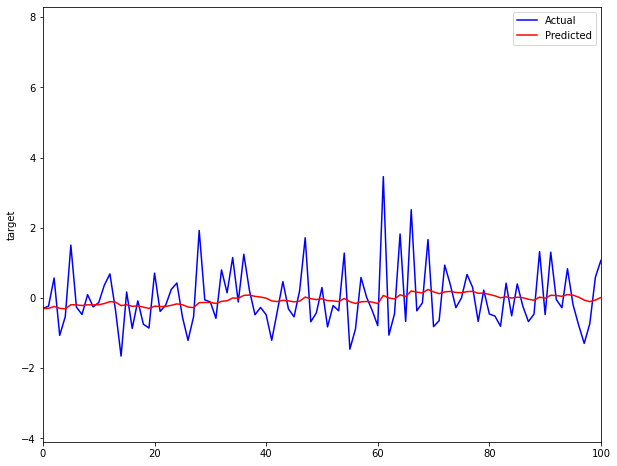

```python
fig1 = plt.figure(figsize=(10,8))
ax1 = fig1.add_subplot(111,ylabel='target')
data['target'].plot(ax=ax1, color='b', label="Actual")
exp_moving_avg.plot(ax=ax1, color='r', label="Predicted")
plt.xlim(0,100)
plt.legend()
plt.show()
```

```python
from sklearn import metrics
print('Mean Absolute Error (MAE): ', metrics.mean_absolute_error(new_df['target'],exp_moving_avg))
print('Mean Squared Error (MSE): ', metrics.mean_squared_error(new_df['target'],exp_moving_avg))
print('Root Mean Squared Error (RMSE): ', np.sqrt(metrics.mean_squared_error(new_df['target'],exp_moving_avg)))
```

```
Mean Absolute Error (MAE):  0.6450389030746332
Mean Squared Error (MSE):  0.7976945483005927
Root Mean Squared Error (RMSE):  0.8931374744688484
```